# Event Driven Production Game

```python
"""
Here we do MCTS inside and SFT-Net class.

The action is selected within the
receive message method of the players
"""

class SFTNet(object):
    def __init__(self, player1, player2, market):
        self.player1 = player1
        self.player2 = player2
        self.market = market
        self.possible_events = [self.market.statechanges[0]]
        self.event_times = []
        self.event_rewards = []

    def reset(self):
        self.market.state = 4
        self.possible_events = [self.market.statechanges[0]]
        self.player1.state = 0
        self.player2.state = 0

        #Use these to keep track of
        # states, rewards and such
        self.event_times = [0]
        self.event_rewards = []
        self.player1_sig = []
        self.player2_sig = []
        self.player1action = []
        self.player2action = []
        self.player1_act_times = []
        self.player2_act_times = []
        self.eventcoll = ['Start']

    def mcts(self, numsamps, depth, burnin=10):
        for _ in range(numsamps):
            self.reset()
            t=0
            reward_start_time = 0
            res = self.simulate(depth,0 )
            self.fill_in_MCTS(burnin=burnin)
        return res

    def simulate(self, depth, t):

        while depth > 0 :
            # First get the next event and the event time
            event_probs = np.asarray([x.rate for x in self.possible_events])
            event_probs = event_probs/float(np.sum(event_probs))
            event = np.random.choice(self.possible_events, p = event_probs)
            newt = t+  np.random.exponential(1./np.sum(event_probs))
            self.event_times.append(newt)
            self.eventcoll.append(event)
            if event.etype == 'StateChange':
                # If we have a spontaneous change
                old_mkt_state = copy.deepcopy(self.market.state)
                # Also changes the state of the market
                self.possible_events.extend(self.market.change_state())

                # This will all be for before the state change
                timeinstate = newt-t # Old state to new state

                # This is the price before the state change
                price = max(0, self.market.market_intercept - old_mkt_state* (self.player1.state +
                                                                      self.player2.state))

                # The reward accumulated between the current event and the previous
                # event.  Discounted to the time of the PREVIOUS Event
                prev_period_reward = [p.reward(p.state, price, timeinstate)
                                   for p in [self.player1, self.player2]]
                self.event_rewards.append(prev_period_reward)
                #self.player1state.append(self.player1.state)
                #self.player2state.append(self.player2.state)
                #self.player1_sig.append(self.player1_sig[-1])
                #self.player2_sig.append(self.player2_sig[-1])

            if (event.etype == 'Message') and (event.receiver =='Player 1'):
                # Case when a firm receives a market signal.
                # Can probably copy and paste for player 2
                self.player1_act_times.append(newt)
                self.possible_events.remove(event) # Remve the event
                self.player1_sig.append(event.content) # Keep track of the signal
                outmsg = self.player1.receive_message_and_react(event) # Send a new message
                self.possible_events.append(outmsg) # Add to possible events

                self.player1action.append(outmsg.content)
                timeinstate = newt-t # Old state to new state
                price = max(0, self.market.market_intercept -
                            self.market.state* (self.player1.state + self.player2.state))
                prev_period_reward = [p.reward(p.state, price, timeinstate)
                                   for p in [self.player1, self.player2]]
                self.event_rewards.append(prev_period_reward)
                #self.player1state.append(copy.copy(self.player1.state))
                #self.player2state.append(copy.copy(self.player2.state))
                #self.player2_sig.append(copy.copy(self.player2_sig[-1]))

            if (event.etype == 'Message') and (event.receiver =='Player 2'):
                # Case when a firm receives a market signal.
                self.player2_act_times.append(newt) # Keep trac of (re)act times
                self.possible_events.remove(event) # Remve the event
                self.player2_sig.append(event.content) # Keep track of the signal
                outmsg = self.player2.receive_message_and_react(event) # Send a new message
                self.possible_events.append(outmsg) # Add to possible events
                self.player2action.append(outmsg.content)
                timeinstate = newt-t # Old state to new state
                price = max(0, self.market.market_intercept -
                            self.market.state* (self.player1.state + self.player2.state))
                prev_period_reward = [p.reward(p.state, price, timeinstate)
                                   for p in [self.player1, self.player2]]
                self.event_rewards.append(prev_period_reward)
                #self.player1state.append(copy.copy(self.player1.state))
                #self.player2state.append(copy.copy(self.player2.state))
                #self.player1_sig.append(copy.copy(self.player1_sig[-1]))

            if (event.etype == 'Message') and (event.sender =='Player 1'):
                # Case when a firm receives a market signal.
                # Can probably copy and paste for player 2
                self.possible_events.remove(event) # Remve the event
                timeinstate = newt-t # Old state to new state
                price = max(0, self.market.market_intercept -
                            self.market.state* (self.player1.state + self.player2.state))
                prev_period_reward = [p.reward(p.state, price, timeinstate)
                                   for p in [self.player1, self.player2]]
                # Update the player's state (quantity currently in market)
                self.player1.state = event.content
                self.event_rewards.append(prev_period_reward)
                # self.player1state.append(copy.copy(self.player1.state))
                # self.player2state.append(copy.copy(self.player2.state))
                # self.player1_sig.append(copy.copy(self.player1_sig[-1]))
                # self.player2_sig.append(copy.copy(self.player2_sig[-1]))

            if (event.etype == 'Message') and (event.sender =='Player 2'):
                # Case when a firm receives a market signal.
                # Can probably copy and paste for player 2
                self.possible_events.remove(event) # Remve the event
                timeinstate = newt-t # Old state to new state
                price = max(0, self.market.market_intercept -
                            self.market.state* (copy.copy(self.player1.state) +
                                                copy.copy(self.player2.state)))
                prev_period_reward = [p.reward(p.state, price, timeinstate)
                                   for p in [self.player1, self.player2]]

                # Update the player's state (quantity currently in market)
                self.player2.state = event.content
                ## Really what is happening is the market is sending a message
                ## back to the node and letting it know the quantity is "live".
                self.event_rewards.append(prev_period_reward)

            t = newt
            depth -= 1
        self.event_rewards.append([0,0]) # Won't record last action's rewards...
        ## Just for accounting sake.


    def fill_in_MCTS(self, burnin=1):
        # First for player 1
        self.player1._content_tomsg()
        self.player2._content_tomsg()
        for ix, time in enumerate(self.player1_act_times[:-burnin]):
            time_ix = self.event_times.index(time) # Index of event
            action = self.player1action[ix]
            action_ix = self.player1.msgcontent.index(action)
            rewards = [r[0] for r in self.event_rewards[time_ix : ]]
            discounttimes = np.asarray(self.event_times[time_ix:]) - time
            #print rewards, discounttimes
            entry_key = self.player1.ctm[self.player1_sig[ix]]
            totalreward = rewards/(1.+self.player1.discount)**discounttimes
            self.player1.MCTS_Counts[entry_key][0][action_ix] += ( (
                    np.sum(totalreward) -self.player1.MCTS_Counts[entry_key][0][action_ix]) /
                    float(self.player1.MCTS_Counts[entry_key][1][action_ix]))
            self.player1.MCTS_Counts[entry_key][1][action_ix] += 1


        # Now player 2
        for ix, time in enumerate(self.player2_act_times[:-burnin]):
            time_ix = self.event_times.index(time) # Index of event
            action = self.player2action[ix]
            action_ix = self.player2.msgcontent.index(action)
            rewards = [r[1] for r in self.event_rewards[time_ix : ]]
            discounttimes = np.asarray(self.event_times[time_ix:]) - time
            #print rewards, discounttimes
            entry_key = self.player2.ctm[self.player2_sig[ix]]
            totalreward = rewards/(1.+self.player2.discount)**discounttimes
            self.player2.MCTS_Counts[entry_key][0][action_ix] += ( (
                    np.sum(totalreward) -self.player2.MCTS_Counts[entry_key][0][action_ix]) /
                    float(self.player2.MCTS_Counts[entry_key][1][action_ix]))
            self.player2.MCTS_Counts[entry_key][1][action_ix] += 1


def get_policy(mcts_res):
    r = {}
    for key, val in mcts_res.iteritems():
        r[key.content] =  np.argmax(val[0]) + 1
    return r
```

# Experiment 1 - Stackelberg-ish

```python
# Parameters
lambdam = .25 # Rate at which market changes state
market_slope = [1,2,3,4,5] # Only slope changes;
market_intercept = 50.
market_to_p1 = 50000
market_to_p2 = 100
p1_to_market = 50000
p2_to_market= 100
cost=1.
def drawmkt(params):
    np.random.choice(params)
pispon = drawmkt
choiceset = np.arange(1, 20 ,1)
discount=.25
c = 100000.

# Setup
p1msgs = []
for elem in choiceset:
    p1msgs.append(Message('Player 1', 'Market', elem, p1_to_market))

p2msgs = []
for elem in choiceset:
    p2msgs.append(Message('Player 2', 'Market', elem, p2_to_market))

mktmsgs = []
for to in ['Player 1', 'Player 2']:
    if to == 'Player 1':
        rate = market_to_p1
    else :
        rate = market_to_p2
    for msg in market_slope:
        mktmsgs.append(Message('Market', to, msg, rate))
sponstate = StateChange('Market', lambdam, 'Market Demand Change')
player1 = Player(p1_to_market, discount, p1msgs, c=c, cost=cost)
player2 = Player(p2_to_market, discount, p2msgs, c=c, cost=cost)
market = Market(market_to_p1, market_to_p2, market_slope, market_intercept, mktmsgs, [sponstate])

#Initialization
Net=SFTNet(player1, player2, market)

#Training
a=Net.mcts(2500,1000, burnin=20)
```

```python
get_policy(Net.player1.MCTS_Counts)
```

```
{1: 16, 2: 8, 3: 7, 4: 5, 5: 3}
```

```python
def set_optimals(net, stack=False):
    net.player1.c = 0
    net.player2.c = 0
    old_mcts = [copy.deepcopy(net.player1.MCTS_Counts), copy.deepcopy(net.player2.MCTS_Counts)]
    # Player 1 first
    if not stack:
        for key, val in net.player1.MCTS_Counts.iteritems():
            val[1] = val[1]*0 + 1
            maxix = np.argmax(val[0])
            val[0] = val[0]*0
            val[0][maxix] = 1

        for key, val in net.player2.MCTS_Counts.iteritems():
            val[1] = val[1]*0 + 1
            maxix = np.argmax(val[0])
            val[0] = val[0]*0
            val[0][maxix] = 1
    else:
        for key, val in net.player1.MCTS_Counts.iteritems():
            val[1] = val[1]*0 + 1
            val[0] = val[0]*0

            if key.content == 1:
                val[0][18] =1
            if key.content ==2 :
                val[0][11] =1
            if key.content ==3:
                val[0][4] = 1
            if key.content ==4:
                val[0][2] =1
            if key.content ==5:
                val[0][1] =1
        for key, val in net.player2.MCTS_Counts.iteritems():
            val[1] = val[1]*0 + 1
            val[0] = val[0]*0

            if key.content == 1:
                val[0][14] =1
            if key.content ==2 :
                val[0][5] =1
            if key.content ==3:
                val[0][2] = 1
            if key.content ==4:
                val[0][1] =1
            if key.content ==5:
                val[0][0] =1

    return old_mcts
```

```python
def get_expected_utility(net, depth, burnin, nsamps, stack=False):
    """
    MCTS gets reset by set_optimals
    """
    set_optimals(net, stack)
    p1_utils = []
    p2_utils = []
    for j in range(nsamps):
        net.mcts(1, depth, burnin=burnin)
        p1u = [x[0] for x in net.event_rewards]
        p2u = [x[1] for x in net.event_rewards]
        times = net.event_times
        p1_utils.append(np.sum(np.asarray(p1u * np.exp(-net.player1.discount * np.asarray(times)))))
        p2_utils.append(np.sum(np.asarray(p2u * np.exp(-net.player2.discount * np.asarray(times)))))
    return p1_utils, p2_utils
```

```python
u1 = get_expected_utility(Net, 1000, 20, 400)
u2 = get_expected_utility(Net, 1000, 20, 400, stack=True)
```

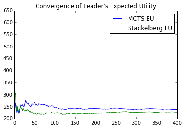

```python
fig, ax = plt.subplots()
ax.plot(np.cumsum(u1[0])/ np.float_(np.arange(1, len(u1[0])+ 1,1 )), label='MCTS EU')
ax.plot(np.cumsum(u2[0])/ np.float_(np.arange(1, len(u2[0])+ 1,1 )), label = 'Stackelberg EU')
ax.set_title('Convergence of Leader\'s Expected Utility')
plt.legend()
```

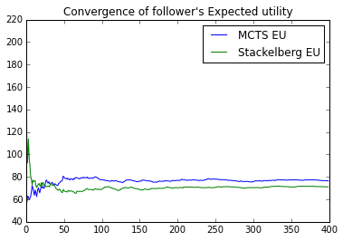

```python
fig, ax = plt.subplots()
ax.plot(np.cumsum(u1[1])/ np.float_(np.arange(1, len(u1[1])+ 1,1 )), label='MCTS EU')
ax.plot(np.cumsum(u2[1])/ np.float_(np.arange(1, len(u2[1])+ 1,1 )), label = 'Stackelberg EU')
ax.set_title('Convergence of follower\'s Expected utility')
plt.legend()
```

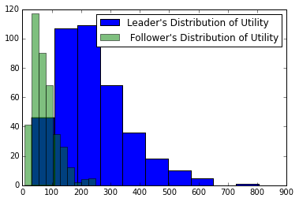

```python
fig, ax = plt.subplots()
ax.hist(u1[0], label = 'Leader\'s Distribution of Utility')
ax.hist(u1[1], label = ' Follower\'s Distribution of Utility', alpha=.5)
plt.legend()
```

### What happens when the "leader/follower' relationship becomes less clear...

Here, there is still a leader (i.e. receives messages faster and sends messages faster) but there is a non-negligible probability that he doesn't act first

```python
# Parameters
lambdam = .25 # Rate at which market changes state
market_slope = [1,2,3,4,5] # Only slope changes;
market_intercept = 50.
market_to_p1 = 50000
market_to_p2 = 20000
p1_to_market = 50000
p2_to_market= 20000
cost=1.
def drawmkt(params):
    np.random.choice(params)
pispon = drawmkt
choiceset = np.arange(1, 20 ,1)
discount=.25
c = 100000.

# Setup
p1msgs = []
for elem in choiceset:
    p1msgs.append(Message('Player 1', 'Market', elem, p1_to_market))

p2msgs = []
for elem in choiceset:
    p2msgs.append(Message('Player 2', 'Market', elem, p2_to_market))

mktmsgs = []
for to in ['Player 1', 'Player 2']:
    if to == 'Player 1':
        rate = market_to_p1
    else :
        rate = market_to_p2
    for msg in market_slope:
        mktmsgs.append(Message('Market', to, msg, rate))
sponstate = StateChange('Market', lambdam, 'Market Demand Change')
player1 = Player(p1_to_market, discount, p1msgs, c=c, cost=cost)
player2 = Player(p2_to_market, discount, p2msgs, c=c, cost=cost)
market = Market(market_to_p1, market_to_p2, market_slope, market_intercept, mktmsgs, [sponstate])

#Initialization
Net=SFTNet(player1, player2, market)

#Training
a=Net.mcts(2500,1000, burnin=20)
```

```python
u3 = get_expected_utility(Net, 1000, 20, 400)
u4 = get_expected_utility(Net, 1000, 20, 400, stack=True)
```

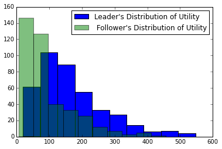

```python
fig, ax = plt.subplots()
ax.hist(u3[0], label = 'Leader\'s Distribution of Utility')
ax.hist(u3[1], label = ' Follower\'s Distribution of Utility', alpha=.5)
plt.legend()
```

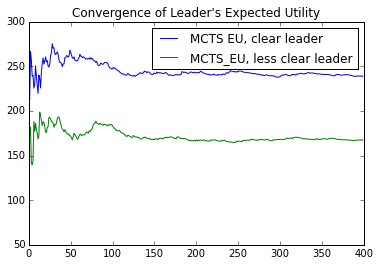

```python
fig, ax = plt.subplots()
ax.plot(np.cumsum(u1[0])/ np.float_(np.arange(1, len(u1[0])+ 1,1 )), label='MCTS EU, clear leader')
ax.plot(np.cumsum(u3[0])/ np.float_(np.arange(1, len(u3[0])+ 1,1 )), label = 'MCTS_EU, less clear leader')
ax.set_title('Convergence of Leader\'s Expected Utility')
plt.legend()
```

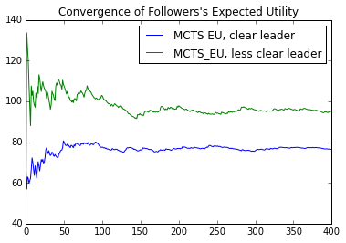

```python
fig, ax = plt.subplots()
ax.plot(np.cumsum(u1[1])/ np.float_(np.arange(1, len(u1[0])+ 1,1 )), label='MCTS EU, clear leader')
ax.plot(np.cumsum(u3[1])/ np.float_(np.arange(1, len(u3[0])+ 1,1 )), label = 'MCTS_EU, less clear leader')
ax.set_title('Convergence of Followers\'s Expected Utility')
plt.legend()
```

### Known Issues

This model is far from the perfect rationality model for the same reason we keep running into.

- To summarize, the policies of the player's are mappings from messages generated by the market to production quantities.
- Players do not know what quantity the other player is producing and the messages the other receives.
- Receiving a message from the market does not constitute an 'information state'. As a simple example:
  - Suppose the relative rate of message transmission is much higher than the rate of demand shocks.
  - Suppose player 1 receives 2 messages only a short time apart. Therefore, player 1 "believes" with a high probability that he has received a new market signal before player 2. He would then select his quantity based on what he believes player 2 will do when he receives his message.
  - On the other hand, suppose that player 1 receives messages "far enough" apart that he is convinced that player 2 already received a message from the market. He will now choose his quantity under the assumption that player 2 already acted. This quantity is likely to be different than when he is under the "belief" that he is acting before player two.

**The bottom line is if timing matters then players, in general, will have to keep track of time. Since time is continuous, this means the state of the player will be continuous. Of course, we can grid up the time, but then we return to discrete time and the benefit of continuous time is lost**

More generally, for the players to be perfectly rational in a game where the state of all variables in the system is unknown, they will have to keep a record of all state changes and messages received along with the times.

**Computational Note**

If we revisit states in an infinite horizon game, we need a "burn out" at the end. In other words, we cannot update the last rewards because it will not include future rewards and bias down the average

[output not shown]